# Gawron_Homework10

Nicholas Gawron

4/6/2021

## Question 1

### Regression Estimation (Part A)

Note that our b calculation is nothing more than:

$$b = \frac{\sum_{i=1}^{n}(x_i-\bar{x})(y_i-\bar{y})}{(n-1)S_x^2}$$

- Note that $S_X^2$ is calculated by computing `sd(dogtimess$x)^2`
- Our variable $a$ comes from the line: `a<- mean(dogtimes$y)-b*mean(dogtimes$x)`

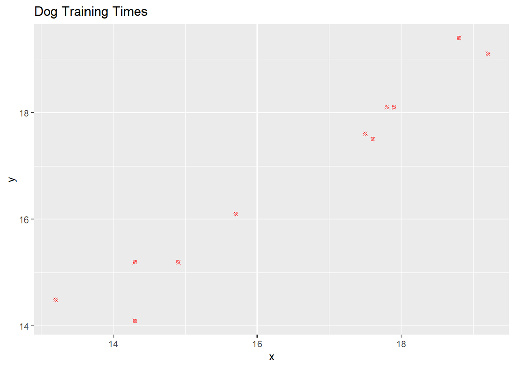

```r
StdDog <- c(14.3, 15.7 ,17.8 ,17.5 ,13.2 ,18.8 ,17.6 ,14.3 ,14.9 ,17.9 ,19.2)
NewDog<- c(15.2, 16.1, 18.1, 17.6, 14.5, 19.4, 17.5, 14.1, 15.2, 18.1, 19.1)

dogtimes <- as_tibble(data.frame(x = StdDog, y= NewDog))
ggplot(data =dogtimes, aes(x =x, y =y))+geom_point(pch =13, col= "red")+
  labs(title= "Dog Training Times", xlab = "Standard", ylab ="New Dog Training")
```

```r
MuX<-17 #given
N<- 700 #given population
n<-as.numeric(length((dogtimes$x))) #Sample size calculation

#calculates b
b <- sum((dogtimes$y - mean(dogtimes$y))*(dogtimes$x - mean(dogtimes$x)))/((n-1)*(sd(dogtimes$x)^2))


MuY <- mean(dogtimes$y)+b*(MuX-mean(dogtimes$x));MuY
```

```
## [1] 17.2769
```

```r
a<- mean(dogtimes$y)-b*mean(dogtimes$x)

MSE<- (sum((dogtimes$y - (a+b*dogtimes$x))^2))/(n-2)
VarMuY <- (1-n/N)*(MSE/n); VarMuY
```

```
## [1] 0.01519949
```

```r
BMuY<- 2*sqrt(VarMuY); BMuY
```

```
## [1] 0.2465724
```

- Our output for $\mu_y$ is 17.2769032
- Our output for ${Var}_y$ is 0.0151995
- Our output for $B_{\mu_y}$ is 0.2465724

```r
model1<-lm(NewDog~StdDog)
a <-  model1$coefficients[1];a<-as.numeric(a);a
```

```
## [1] 2.19399
```

```r
b<-model1$coefficients[2];b<-as.numeric(b);b
```

```
## [1] 0.8872302
```

### Differnece Estimation (Part B)

```r
#Computes the difference variable d
d<- dogtimes$y-dogtimes$x;
dBAR<- mean(dogtimes$y)-mean(dogtimes$x);

MuYDiff <- MuX+ dBAR; MuYDiff
```

```
## [1] 17.33636
```

```r
VarMuYDiff <- (1-n/N)*(1/n)*((sum((d-dBAR)^2)))/(n-1)
VarMuYDiff
```

```
## [1] 0.01848179
```

```r
BMuYDiff <- 2*sqrt(VarMuYDiff); BMuYDiff
```

```
## [1] 0.2718955
```

- Our output for $\mu_{y,D}$ is 17.3363636
- Our output for ${Var}_{y,D}$ is 0.0184818
- Our output for $B_{\mu_{y,D}}$ is 0.2718955

## Question 2

### Regression

Total In Regression:
$$\begin{align*}
\mu_{Y,L} &= \bar{y}+b(\mu_x-\bar{x})\\
N\mu_{Y,L} &= N(\bar{y}+b(\mu_x-\bar{x}))\\
\tau_{Y,L} &= N\bar{y}+b(\tau_x-N\bar{x})\\
\end{align*}$$

Variance in model:

$$\begin{align*}
Var(\mu_{Y,L}) &= (1 - \frac{n}{N})(\frac{MSE}{n})\\
(N^2)Var(\mu_{Y,L})&= (N^2) (1 - \frac{n}{N})(\frac{MSE}{n})\\
Var(N\mu_{Y,L}) &= \\
Var(\tau_{Y,L}) &=(N^2) (1 - \frac{n}{N})(\frac{MSE}{n})
\end{align*}$$

### Difference estiamation

Total:

$$\begin{align*}
\mu_{y,D} &= \bar{y} +(\mu_x-\bar{x}) = \mu_x +\bar{d}\\
N\mu_{y,D} &= N(\bar{y} +(\mu_x-\bar{x}) = \mu_x +\bar{d})\\
\tau_{y,D} &= N\bar{y}+(\tau_x-N\bar{x}) = \tau_x + N\bar{d}
\end{align*}$$

Variance:
$$\begin{align*}
Var(\tau_{Y,D}) &= Var(N\mu_{Y,D})\\
&= N^2(Var(\mu_{Y,D}))\\
&=N^2(1-\frac{n}{N})(\frac{1}{n})(\frac{\sum_{i}^{n}(d_i-\bar{d})^2}{n-1})
\end{align*}$$

## Question 3

### Dead Firs Regression (Part A)

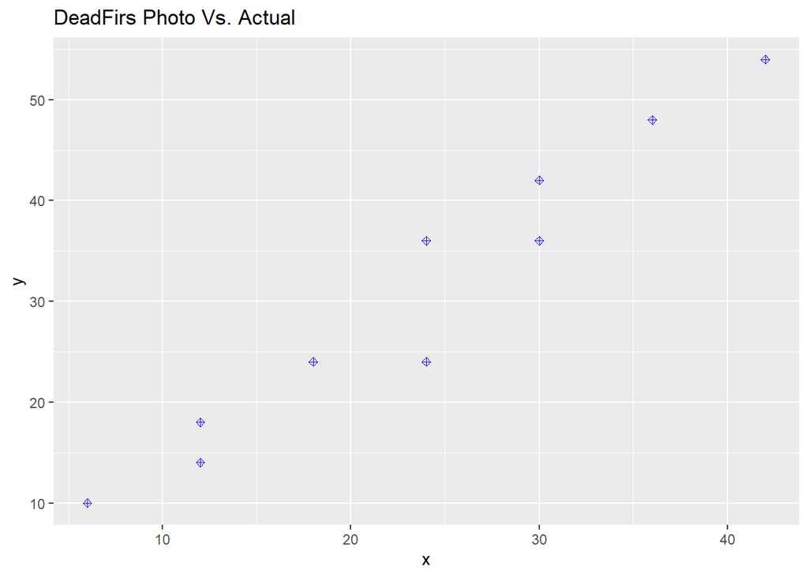

```r
Pct <- c(12, 30, 24, 24, 18, 30, 12, 6, 36, 42)
Act <- c(18 ,42 ,24 ,36 ,24 ,36, 14 ,10 ,48 ,54)
DeadFirs <- as_tibble(data.frame(x = Pct, y= Act))
ggplot(data =DeadFirs, aes(x =x, y =y))+geom_point(pch =9, col= "blue")+
  labs(title= "DeadFirs Photo Vs. Actual", xlab = "Photo", ylab ="Actual")
```

```r
model1<-lm(Act~Pct)
# This creates
a <-  model1$coefficients[1];a<-as.numeric(a)
b<-model1$coefficients[2];b<-as.numeric(b)





MuX<-4200/200 #given Mu
N<- 200 #given population  of acres
n<-as.numeric(length((DeadFirs$x))) #Sample size calculation

#calculates b
b <- sum((DeadFirs$y - mean(DeadFirs$y))*(DeadFirs$x - mean(DeadFirs$x)))/((n-1)*(sd(DeadFirs$x)^2))



MuY <- mean(DeadFirs$y)+b*(MuX-mean(DeadFirs$x));
TauY <- N*MuY; TauY
```

```
## [1] 5515.502
```

```r
a<- mean(DeadFirs$y)-b*mean(DeadFirs$x)

MSE<- (sum((DeadFirs$y - (a+b*DeadFirs$x))^2))/(n-2)
VarMuY <- (1-n/N)*(MSE/n); VarMuY
```

```
## [1] 1.257812
```

```r
VarTot<- (N^2)*VarMuY
BTotY<- 2*sqrt(VarTot); BTotY
```

```
## [1] 448.6088
```

### Conclusion on Question 3 (Part B)

We note that our bound on the error of estimation that was calculated under ratio estimation is `428.4381371`. We will assume this value is correct. We further note that our bound on the error of estimation for ratio estimation is less than our bound created in the previous part (448.6087917). Due to the fact that the bound of error is less for ratio estimation total than it was for regression estimation of the total - we conclude that ratio estimation is more appropriate here.

## Question 4

It is important to note that we have do **not** have a randomly ordered data set. In partiaular this mortgage data is ordered with a general positive trend across serial number - since prices rose year by year.

A systematic sample for a random population behaves, for all practical purposes, like a simple random sample. So, in that case, the variance approximation using the formula from simple random sampling works well. In samples from an ordered population, the sample values will tend to be further apart numerically than in a simple random sample, making the within-sample correlation, $\rho$, negative. If we took a systematic sample for the mortgage data; each sample will have some of the smaller values as well as some of the larger values, which would not necessarily happen in a simple random sample. This implies that the systematic sampling mean will have a smaller variance than the one for simple random sampling, so that the use of the simple random sampling formula produces an overestimate of the true sampling error.